# US School Diversity

Ljupcho Naumov - Ljupcho.com

October 6th, 2019

```r
library("tidyverse")
library("ggthemes")
```

Dataset

```r
school_diversity <- read_csv("https://github.com/rfordatascience/tidytuesday/blob/master/data/2019/2019-09-24/school_diversity.csv?raw=true")
```

Variable name standardization to lowercase, renamed variable “st” to “state” for code readability.

```r
names(school_diversity) <- tolower(names(school_diversity))
names(school_diversity)[3] <- "state"
```

1:New Dataset with variable that counts the number of Extremely undiverse, Undiverse, and Diverse schools by state and year. 2:New variable is added that calculates proportions of Extrem. Undiverse, Undiverse and Diverse schools by state and year. 3: Set diversity and school_year to a factor in order to change order of the levels so they appear in the graphs correctly (1st extremely undiverse, diverse last).

```r
#1
state_by_diversity <- school_diversity %>%
  group_by(state, school_year, diverse) %>%
  summarize(diversity_count = n())

#2
state_by_diversity <- state_by_diversity %>%
  group_by(state, school_year) %>%
  mutate(diversity_prop = diversity_count/sum(diversity_count))

#3
state_by_diversity$diverse <- factor(state_by_diversity$diverse, levels=c("Diverse","Undiverse","Extremely undiverse"))

school_diversity$diverse <- factor(school_diversity$diverse, levels=c("Diverse","Undiverse","Extremely undiverse"))
```

Bare bones graph for just 1994-1995 for every state, no faceting.

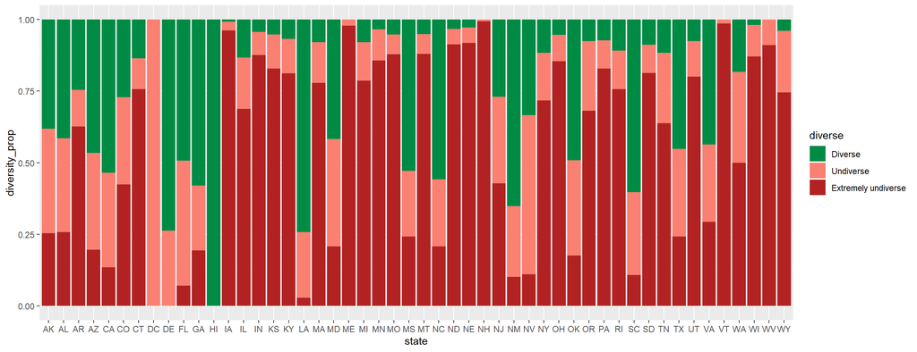

```r
ggplot(data= state_by_diversity %>% filter(school_year=="1994-1995"))+
  geom_col(mapping=aes(x=state, y=diversity_prop, fill=diverse))+
  scale_fill_manual(values= c("Diverse" = "springgreen4","Extremely undiverse"="firebrick",Undiverse="salmon"))
```

The same graph but with the original dataset.

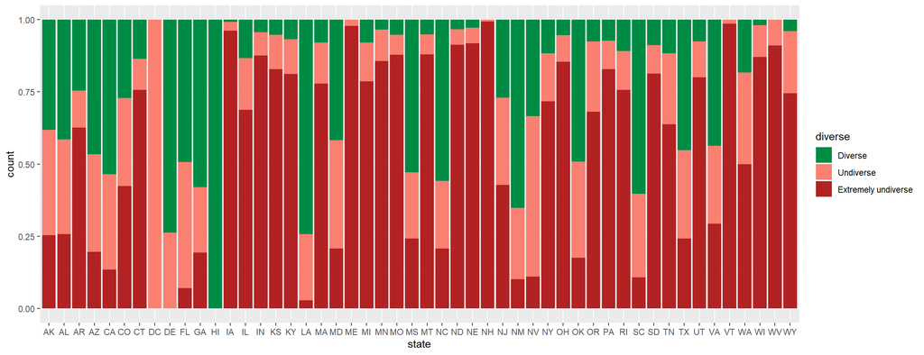

```r
ggplot(data = school_diversity %>% filter(school_year=="1994-1995"))+
  geom_bar(mapping = aes(x = state, fill = diverse), position = "fill")+
  scale_fill_manual(values= c("Diverse" = "springgreen4","Extremely undiverse"="firebrick",Undiverse="salmon"))
```

Bare bones graph for 2016-2017

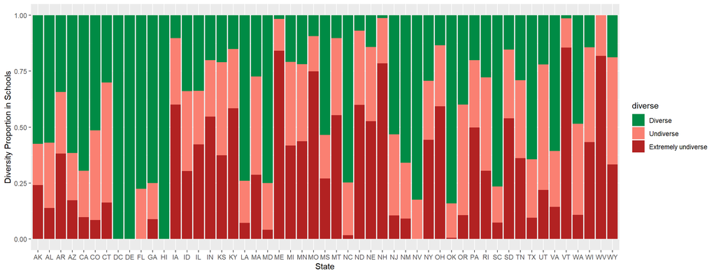

```r
ggplot(data= state_by_diversity %>% filter(school_year=="2016-2017"))+
  geom_col(aes(x=state, y=diversity_prop, fill=diverse))+
  scale_fill_manual(values= c("Diverse" = "springgreen4","Extremely undiverse"="firebrick",Undiverse="salmon"))+
  labs(x="State",y="Diversity Proportion in Schools")
```

Full graph with facet by year. There is missing data for Idaho for 1994-1995.

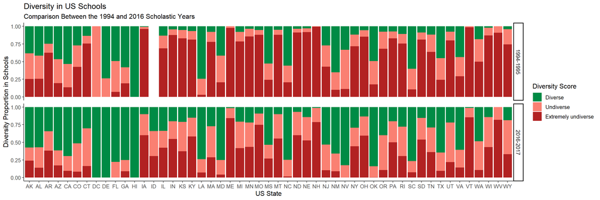

```r
ggplot(data=state_by_diversity)+
  geom_col(aes(x=state, y=diversity_prop, fill=diverse))+
  facet_grid(school_year ~ .)+
  scale_fill_manual(values= c("Diverse" = "springgreen4","Extremely undiverse"="firebrick",Undiverse="salmon"))+
  labs(title="Diversity in US Schools",subtitle="Comparison Between the 1994 and 2016 Scholastic Years", x="US State", y="Diversity Proportion in Schools",fill="Diversity Score")+
  theme_classic()+
  theme(text = element_text(size=12))
```

Saves the graph to your working directory.

```r
ggsave("Diversity_US_Schools_1995_2016_by_year.png", width = 15, height = 5)
```

Full Graph with facet by state.

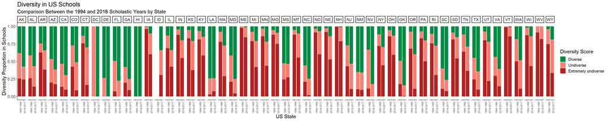

```r
ggplot(data=state_by_diversity)+
  geom_col(aes(x=school_year, y=diversity_prop, fill=diverse))+
  facet_grid(~ state)+
  #Everything below is looks
  scale_fill_manual(values= c("Diverse" = "springgreen4","Extremely undiverse"="firebrick",Undiverse="salmon"))+
  labs(title="Diversity in US Schools",subtitle="Comparison Between the 1994 and 2016 Scholastic Years by State", x="US State", y="Diversity Proportion in Schools",fill="Diversity Score")+
  theme_classic()+
  theme(text = element_text(size=15))+
  theme(axis.text.x = element_text(angle = 90))+
  theme(axis.text.x = element_text(size = 7))
```

Same graph, but with simplified code. By using geom_bar with the original dataset instead of geom_col with our wrangled dataset, ggplot does the heavy lifting for us.

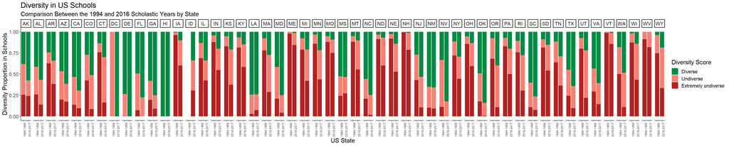

```r
ggplot(data=school_diversity)+
  geom_bar(mapping = aes(x = school_year, fill = diverse), position = "fill")+
  facet_grid(~ state)+
  #Everything below is looks
  scale_fill_manual(values= c("Diverse" = "springgreen4","Extremely undiverse"="firebrick",Undiverse="salmon"))+
  labs(title="Diversity in US Schools",subtitle="Comparison Between the 1994 and 2016 Scholastic Years by State", x="US State", y="Diversity Proportion in Schools",fill="Diversity Score")+
  theme_classic()+
  theme(text = element_text(size=15))+
  theme(axis.text.x = element_text(angle = 90))+
  theme(axis.text.x = element_text(size = 7))
```

Saves the graph to your working directory

```r
ggsave("Diversity_US_Schools_1995_2016_by_state.png", width = 22, height = 5)
```